# Exploitation des données Sunshine

Pour info, Les carrés gris contiennent le code informatique qui a permis de calculer les statistiques présentées ici.

```python
#ces parties représente le code utilisé pour réaliser l'exploitation ci dessous
import sys
import pandas as pd
import numpy as np
import json

def labos2AvantagesAndConventions(file):
    labo = pd.read_csv(file, encoding='utf-8')
    labo['BENEF_PS_QUALIFICATION'][labo['ORIGIN'] == 'Pharmacien'] = "Pharmacien"

    avantages = pd.DataFrame()
    if labo.DECL_AVANT_DATE.count() != 0:
        laboa = labo[labo.DECL_AVANT_DATE != 'None']
        laboa = laboa.dropna(subset = ['DECL_AVANT_DATE'])
        laboa = laboa[laboa.DECL_AVANT_DATE.str.contains(r'^20\d\d-')]
        avantages = laboa[['LABO', 'DECL_AVANT_DATE','DECL_AVANT_MONTANT', 'BENEF_PS_QUALIFICATION', 'ORIGIN']]
        avantages.index = pd.to_datetime(avantages['DECL_AVANT_DATE'])

    conventions = pd.DataFrame()
    if labo.DECL_CONV_DATE.count() != 0:
        laboc = labo[labo.DECL_CONV_DATE != 'None']
        laboc = laboc.dropna(subset = ['DECL_CONV_DATE'])
        laboc = laboc[laboc.DECL_CONV_DATE.str.contains(r'^20\d\d-')]
        conventions = laboc[['LABO', 'DECL_CONV_DATE','DECL_CONV_OBJET', 'BENEF_PS_QUALIFICATION', 'ORIGIN']]
        conventions.index = pd.to_datetime(conventions['DECL_CONV_DATE'])

    return (conventions, avantages)
```

# GILEAD

```python
#Chargement des données
(conventions, avantages) = labos2AvantagesAndConventions("GILEAD.anon.csv")
```

## Répartition des cadeaux attribuées par Gilead par trimestre (Q)

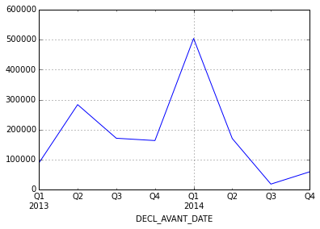

```python
avantages['DECL_AVANT_MONTANT'].resample('BQ', how='sum').plot()
```

*Q = trimestre => Q1 = 1er trimestre*

Deux pics :

- 300 000 € attribués lors du second trimestre 2013
- 500 000 € attribués lors du premier trimestre 2014

## Quels sont les professionnels visés par Giléad ?

```python
professionnels = avantages.groupby(['BENEF_PS_QUALIFICATION'])[['DECL_AVANT_MONTANT']].sum().sort('DECL_AVANT_MONTANT', ascending=False)
tot = professionnels.sum()
professionnels['%'] = professionnels * 100/tot
professionnels.head(10)
```

| BENEF_PS_QUALIFICATION | DECL_AVANT_MONTANT | % |
| --- | --- | --- |
| Médecine générale | 356648 | 49.187604 |
| Hépato-gastro-entérologie | 120879 | 16.671195 |
| Hématologie | 40808 | 5.628092 |
| Médecine infectieuse et tropicale | 37071 | 5.112698 |
| Médecine interne | 31109 | 4.290441 |
| Biologie médicale | 25921 | 3.574931 |
| Anesthésie-réanimation | 22518 | 3.105601 |
| Pédiatrie | 17379 | 2.396849 |
| Infirmier | 16422 | 2.264863 |
| Pharmacien | 14852 | 2.048334 |

La médecine générale semble la grande gagnante avec 356 648 € Viennent ensuite l'hépato (120 879€), l'hémoragie (40 808€), ...

Mais en regardant la répartition des données, on s'aperçoit que la descripion des spécialités des médecins n'est plus renseignée à partir de juillet 2013. Ils semblent avoir tous été regroupés sous la catégorie "médecine générale".

```python
par_profession = pd.DataFrame()
for p in professionnels.head(10).index:
    par_profession[p] = avantages[avantages['BENEF_PS_QUALIFICATION'] == p]['DECL_AVANT_MONTANT'].resample('Q', how='sum')
par_profession
```

| DECL_AVANT_DATE | Médecine générale | Hépato-gastro-entérologie | Hématologie | Médecine infectieuse et tropicale | Médecine interne | Biologie médicale | Anesthésie-réanimation | Pédiatrie | Infirmier | Pharmacien |
| --- | --- | --- | --- | --- | --- | --- | --- | --- | --- | --- |
| 2013-03-31 | 3974 | 30498 | 4796 | 6413 | 5525 | 2817 | 11084 | 4690 | NaN | 1287 |
| 2013-06-30 | 19408 | 90381 | 36012 | 30658 | 25584 | 23104 | 11434 | 12689 | NaN | 5411 |
| 2013-09-30 | 8127 | NaN | NaN | NaN | NaN | NaN | NaN | NaN | 1427 | 651 |
| 2013-12-31 | 73300 | NaN | NaN | NaN | NaN | NaN | NaN | NaN | 1620 | 975 |
| 2014-03-31 | 100955 | NaN | NaN | NaN | NaN | NaN | NaN | NaN | 3440 | 3237 |
| 2014-06-30 | 76172 | NaN | NaN | NaN | NaN | NaN | NaN | NaN | 8107 | 2099 |
| 2014-09-30 | 17071 | NaN | NaN | NaN | NaN | NaN | NaN | NaN | 1176 | 411 |
| 2014-12-31 | 57641 | NaN | NaN | NaN | NaN | NaN | NaN | NaN | 652 | 781 |

Pour mieux comprendre la répartition des cadeaux Giléad par spécialité de médecin, il faut donc se concentrer sur le premier semestre 2013 :

```python
professionnels = avantages[avantages.DECL_AVANT_DATE < "2013-07-01"].groupby(['BENEF_PS_QUALIFICATION'])[['DECL_AVANT_MONTANT']].sum().sort('DECL_AVANT_MONTANT', ascending=False)
tot = professionnels.sum()
professionnels['%'] = professionnels * 100/tot
professionnels.head(10)
```

| BENEF_PS_QUALIFICATION | DECL_AVANT_MONTANT | % |
| --- | --- | --- |
| Hépato-gastro-entérologie | 120879 | 33.101210 |
| Hématologie | 40808 | 11.174763 |
| Médecine infectieuse et tropicale | 37071 | 10.151432 |
| Médecine interne | 31109 | 8.518813 |
| Biologie médicale | 25921 | 7.098143 |
| Médecine générale | 23382 | 6.402870 |
| Anesthésie-réanimation | 22518 | 6.166274 |
| Pédiatrie | 17379 | 4.759023 |
| Anesthésie | 10388 | 2.844625 |
| Pharmacien | 6698 | 1.834164 |

Pour les médecins, le pic des cadeaux a lieu au 2ème trimestre 2013 avec 276 717 €. (pour le 1er trimestre 2014, les cadeaux aux médecins s'élèvent à 100 000 €)

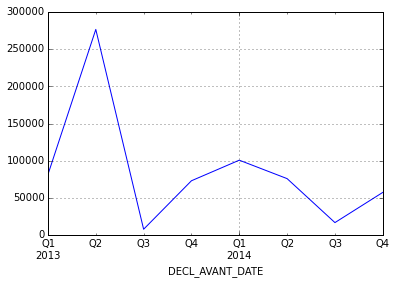

```python
avantages[avantages['ORIGIN'] == u'Médecin']['DECL_AVANT_MONTANT'].resample('Q', how='sum').plot()
```

*Q = trimestre => Q2 = 2ème trimestre*

## Quelle tendance pour les contrats attribués par Giléad ?

Les mêmes spécialités de médecins sont visées :

```python
conventions.groupby(['ORIGIN', 'BENEF_PS_QUALIFICATION'])[['ORIGIN']].count().sort('ORIGIN', ascending=False).head(15)
```

| ORIGIN | BENEF_PS_QUALIFICATION | ORIGIN |
| --- | --- | --- |
| Médecin | Hépato-gastro-entérologie | 218 |
|  | Médecine infectieuse et tropicale | 207 |
|  | Médecine interne | 146 |
|  | Biologie médicale | 80 |
|  | Médecine générale | 59 |
|  | Hématologie | 34 |
|  | Néphrologie | 28 |
|  | Virologie | 24 |
|  | Anesthésie-réanimation | 23 |
|  | Pédiatrie | 19 |
|  | Dermatologie | 16 |
|  | Pneumologie | 12 |
|  | Anesthésie | 12 |
|  | Psychiatrie | 10 |
|  | Bactériologie | 6 |

Une temporalité similaire à celle des médecins (pic 2d trimestre 2013) :

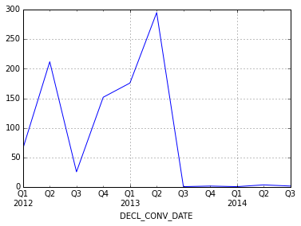

```python
conventions['DECL_CONV_OBJET'].resample('BQ', how='count').plot()
```

## D'où vient le pic du premier trimestre 2014 ?

Dans le 1er graphique sur les avantages distribués, le premier pic correspond à de nombreux cadeaux attribués aux médecins. Par contre, le 2d pic ne peut s'expliquer par une activité visant les médecins. Durant cette période, les montants qui leur ont été consacrés ne représentent que 20% des dépenses.

```python
professionnels = avantages[((avantages.DECL_AVANT_DATE >= "2014-01-01") & (avantages.DECL_AVANT_DATE < "2014-04-01"))].groupby(['ORIGIN'])[['DECL_AVANT_MONTANT']].sum().sort('DECL_AVANT_MONTANT', ascending=False)
tot = professionnels.sum()
professionnels['%'] = professionnels * 100/tot
professionnels.head(10)
```

| ORIGIN | DECL_AVANT_MONTANT | % |
| --- | --- | --- |
| Autres types de personne morale | 247000 | 48.971888 |
| Asso d'usager de santé | 146000 | 28.946946 |
| Médecin | 100955 | 20.016020 |
| Infirmier | 3440 | 0.682038 |
| Pharmacien | 3237 | 0.641789 |
| Asso de prof. de santé | 2500 | 0.495667 |
| Préparateur en pharmacie | 728 | 0.144338 |
| Etudiant | 324 | 0.064238 |
| Sage-femme | 81 | 0.016060 |
| Aide soignant | 56 | 0.011103 |

Durant cette période, **les associations et personnes morales** recoivent le plus d'avantages (78%). En dehors de cette période, ils ne représentent que 29% du montant attribué.

Répartition des avantages attribués aux association et autres personnes morales fait ressentir ce pic de dépense au premier trimestre 2014.

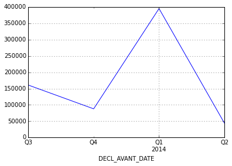

```python
avantages[(avantages['ORIGIN'] == u'Autres types de personne morale') | (avantages['ORIGIN'] == u'Asso de prof. de santé') | (avantages['ORIGIN'] == u'Asso d\'usager de santé')]['DECL_AVANT_MONTANT'].resample('Q', how='sum').plot()
```

*Q = trimestre => Q3 = 3ème trimestre*

## Détail des avantages et conventions aux personnes morales :

```python
pd.read_csv("GILEAD.personnesmorales.csv", encoding='utf-8').sort('date')
```

|  | Nom personne morale | code postal | montant en euros | date | type |
| --- | --- | --- | --- | --- | --- |
| 18 | ACTIPLUS | 95410 | NaN | 2013-07-05 | CONTRAT DE CONSULTANT |
| 2 | BUREAU FEDERATION SOS HEPATITES | 75020 | 22000 | 2013-08-05 | DON |
| 3 | MOUTON DESSINE MOI | 75010 | 25000 | 2013-08-05 | DON |
| 12 | TRAITEMENTS ACTION | 75020 | 50000 | 2013-08-05 | DON |
| 13 | SENI TI | 69008 | 5000 | 2013-08-05 | DON |
| 16 | AFRISANTE | 13001 | 8000 | 2013-08-05 | DON |
| 23 | PREVENTION | 78450 | 20900 | 2013-08-05 | DON |
| 27 | NATIONALE AIDES FEDERATION | 93500 | 30000 | 2013-09-17 | DON |
| 4 | SIDACTION | 75010 | 25000 | 2013-10-03 | DON |
| 8 | VIRALES ASSOCIATION GESTION COLLECTIF HEPATITES | 75020 | 3000 | 2013-10-03 | DON |
| 19 | GRAPHIC SAS DIAMANT | 91420 | NaN | 2013-10-03 | CONTRAT DE CONSULTANT |
| 20 | EDIWARE | 78470 | NaN | 2013-11-08 | CONTRAT DE CONSULTANT |
| 1 | SIDA ALLIANCE CONTRE | 75020 | 13000 | 2013-12-11 | DON |
| 9 | BASILIADE | 75003 | 40000 | 2013-12-11 | DON |
| 15 | ESPOIRS | 75014 | 7000 | 2013-12-20 | DON |
| 28 | SIS | 75020 | 30000 | 2014-01-15 | DON |
| 29 | PREVENTION | 78450 | 30000 | 2014-01-15 | DON |
| 21 | EDIWARE | 78470 | NaN | 2014-02-17 | DIVERS |
| 6 | VLM | 75013 | 30000 | 2014-03-12 | DON |
| 10 | FEDERATION SOS HEPATITES | 75020 | 40000 | 2014-03-12 | DON |
| 14 | SANTE ALTER | 91190 | 6000 | 2014-03-12 | DON |
| 25 | AIDES | 13002 | 25000 | 2014-03-12 | DON |
| 26 | PREVENTION | 78450 | 28000 | 2014-03-12 | DON |
| 30 | AIDES | 13002 | 54000 | 2014-03-12 | DON |
| 31 | AIDES | 13002 | 80000 | 2014-03-12 | DON |
| 7 | SANTE ACTIF | 75020 | 30000 | 2014-03-20 | DON |
| 11 | TRAITEMENTS ACTION | 75020 | 40000 | 2014-03-20 | DON |
| 5 | HEPATOWEB | 94160 | 2500 | 2014-03-27 | DON |
| 0 | FEDERATION SOS HEPATITES | 75020 | 10000 | 2014-05-14 | DON |
| 17 | INDIEN RIVE OCEAN | 97400 | 11452 | 2014-05-14 | DON |
| 24 | SIS | 75020 | 22650 | 2014-05-21 | DON |
| 22 | KANTAR | 78240 | NaN | 2014-06-17 | DIVERS |

# GSK

```python
#Chargement des données
(conventions, avantages) = labos2AvantagesAndConventions("GSK.anon.csv")
```

## Répartition des cadeaux de GSK pour la pédiatrie

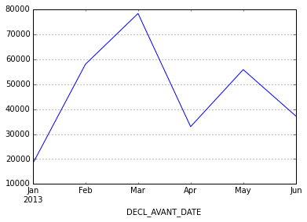

```python
avantages[avantages['BENEF_PS_QUALIFICATION'] == u'Pédiatrie']['DECL_AVANT_MONTANT'].resample('M', how='sum').plot()
```

Deux pics :

- en mars 2013 : près de 80 000 €
- en mai 2013 : plus de 55 000 €

## Répartition dans le temps des contrats

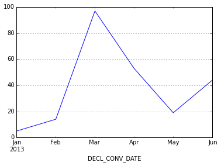

```python
conventions[conventions['BENEF_PS_QUALIFICATION'] == u'Pédiatrie']['DECL_CONV_OBJET'].resample('M', how='count').plot()
```

Un pic en mars 2013, avec près de 100 contrats

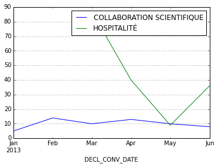

```python
p = pd.DataFrame()
for t in conventions[conventions['BENEF_PS_QUALIFICATION'] == u'Pédiatrie']['DECL_CONV_OBJET'].unique():
    p[t] = conventions[(conventions['BENEF_PS_QUALIFICATION'] == u'Pédiatrie') & (conventions['DECL_CONV_OBJET'] == t)][['ORIGIN']].resample('M', how='count')['ORIGIN']
p.plot()
```

## Comparaison avec les autres professions

Les spécialités des médecins sont renseignées durant le 1er semestre 2013 :

```python
prof = [u'Médecine générale', u'Pédiatrie', u'Pneumologie', u'Urologie', u'Gynécologie']
par_profession = pd.DataFrame()
for p in prof:
    par_profession[p] = avantages[avantages['BENEF_PS_QUALIFICATION'] == p]['DECL_AVANT_MONTANT'].resample('Q', how='sum')
par_profession
```

| DECL_AVANT_DATE | Médecine générale | Pédiatrie | Pneumologie | Urologie | Gynécologie |
| --- | --- | --- | --- | --- | --- |
| 2012-03-31 | 732802 | NaN | NaN | NaN | NaN |
| 2012-06-30 | 829050 | NaN | NaN | NaN | 46 |
| 2012-09-30 | 410435 | NaN | NaN | NaN | NaN |
| 2012-12-31 | 627672 | NaN | NaN | NaN | 68 |
| 2013-03-31 | 657373 | 154684 | 211147 | 156098 | 108607 |
| 2013-06-30 | 1068661 | 126102 | 91725 | 56851 | 37134 |
| 2013-09-30 | 293204 | NaN | NaN | NaN | NaN |
| 2013-12-31 | 767771 | NaN | NaN | NaN | NaN |
| 2014-03-31 | 604328 | NaN | NaN | NaN | NaN |
| 2014-06-30 | 775428 | NaN | NaN | NaN | NaN |
| 2014-09-30 | 8121 | NaN | NaN | NaN | NaN |
| 2014-12-31 | 19434 | NaN | NaN | NaN | NaN |

Durant cette période, les médecins généralistes sont majoritairement visés :

```python
avantages[(avantages.DECL_AVANT_DATE <= '2013-06-30') & (avantages.DECL_AVANT_DATE >= '2013-01-01')].groupby(['BENEF_PS_QUALIFICATION'])[['DECL_AVANT_MONTANT']].sum().sort('DECL_AVANT_MONTANT', ascending=False).head(15)
```

| BENEF_PS_QUALIFICATION | DECL_AVANT_MONTANT |
| --- | --- |
| Médecine générale | 1726034 |
| Pneumologie | 302872 |
| Pédiatrie | 280786 |
| Urologie | 212949 |
| Gynécologie | 145741 |
| Oncologie | 142965 |
| Angiologie | 138230 |
| Oto-rhino-laryngologie | 121647 |
| Médecine interne | 74616 |
| Neurologie | 65296 |
| Allergologie | 63885 |
| Infirmier | 56687 |
| Dermatologie | 35030 |
| Pharmacien | 34710 |
| Cardiologie | 26994 |

Même situation pour les contrats, même si **on repère un pic de contrat avec les Pneumologue au 2d trimestre 2013** (avec 236 contrats signés):

```python
prof = [u'Médecine générale', u'Pédiatrie', u'Pneumologie', u'Urologie', u'Gynécologie']
par_profession = pd.DataFrame()
for p in prof:
    par_profession[p] = conventions[conventions['BENEF_PS_QUALIFICATION'] == p]['DECL_CONV_OBJET'].resample('Q', how='count')
par_profession
```

| DECL_CONV_DATE | Médecine générale | Pédiatrie | Pneumologie | Urologie | Gynécologie |
| --- | --- | --- | --- | --- | --- |
| 2012-03-31 | 48 | NaN | NaN | NaN | NaN |
| 2012-06-30 | 24 | NaN | NaN | NaN | NaN |
| 2012-09-30 | 11 | NaN | NaN | NaN | NaN |
| 2012-12-31 | 30 | NaN | 4 | 4 | NaN |
| 2013-03-31 | 356 | 116 | 147 | 111 | 30 |
| 2013-06-30 | 496 | 116 | 236 | 35 | 82 |
| 2013-09-30 | 487 | NaN | 13 | NaN | NaN |
| 2013-12-31 | 1446 | NaN | 1 | NaN | NaN |
| 2014-03-31 | 1178 | NaN | NaN | NaN | NaN |
| 2014-06-30 | 975 | NaN | NaN | NaN | NaN |
| 2014-09-30 | 1 | NaN | NaN | NaN | NaN |
| 2014-12-31 | 5 | NaN | NaN | NaN | NaN |

# Oncologue / Pédiatrie

```python
(conventions, avantages) = labos2AvantagesAndConventions("OncologiePediatrie.anon.csv")
```

## Le top 15 des labos sur les cadeaux à l'oncologie et la pédiatrie (en euros)

```python
avantages.groupby('LABO')[['DECL_AVANT_MONTANT']].sum().sort('DECL_AVANT_MONTANT', ascending=False).head(15)
```

| LABO | DECL_AVANT_MONTANT |
| --- | --- |
| NOVARTIS PHARMA | 1215286 |
| AMGEN | 738758 |
| GLAXOSMITHKLINE | 423887 |
| PFIZER | 367901 |
| ROCHE | 328696 |
| SANOFI | 287537 |
| NOVEX PHARMA | 285165 |
| IPSEN | 189123 |
| SHIRE | 171420 |
| SANDOZ | 161077 |
| ASTELLAS PHARMA | 143778 |
| ALK-Abello | 131528 |
| JANSSEN CILAG | 128725 |
| TAKEDA | 116251 |
| MUNDIPHARMA | 114515 |

## Top 15 des cadeaux en oncologue (en euros)

```python
avantages[avantages['BENEF_PS_QUALIFICATION'] == 'Oncologie'].groupby('LABO')[['DECL_AVANT_MONTANT']].sum().sort('DECL_AVANT_MONTANT', ascending=False).head(15)
```

| LABO | DECL_AVANT_MONTANT |
| --- | --- |
| NOVARTIS PHARMA | 1003095 |
| AMGEN | 735314 |
| ROCHE | 321234 |
| NOVEX PHARMA | 285165 |
| SANOFI | 264905 |
| PFIZER | 211474 |
| GLAXOSMITHKLINE | 143101 |
| JANSSEN CILAG | 124825 |
| TAKEDA | 115900 |
| MUNDIPHARMA | 102990 |
| ASTELLAS PHARMA | 97093 |
| BOEHRINGER INGELHEIM | 95644 |
| KEOCYT | 93751 |
| IPSEN | 91890 |
| SANDOZ | 71033 |

## Top 15 des cadeaux en pédiatrie (en euros)

```python
avantages[avantages['BENEF_PS_QUALIFICATION'] == u'Pédiatrie'].groupby('LABO')[['DECL_AVANT_MONTANT']].sum().sort('DECL_AVANT_MONTANT', ascending=False).head(15)
```

| LABO | DECL_AVANT_MONTANT |
| --- | --- |
| GLAXOSMITHKLINE | 280786 |
| NOVARTIS PHARMA | 212191 |
| SHIRE | 168816 |
| PFIZER | 156427 |
| ALK-Abello | 131528 |
| CHIESI | 113642 |
| IPSEN | 97233 |
| SANDOZ | 90044 |
| ACTELION | 78862 |
| Genzyme | 65362 |
| ASTELLAS PHARMA | 46685 |
| Lilly | 35446 |
| Cyberonics | 29759 |
| SANOFI | 22632 |
| BAYER | 17662 |

## Répartition des cadeaux dans le temps en Oncologie

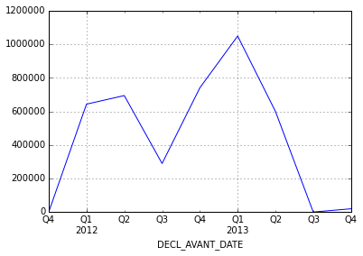

```python
avantages[avantages['BENEF_PS_QUALIFICATION'] == 'Oncologie']['DECL_AVANT_MONTANT'].resample('Q', how='sum').plot()
```

## Répartition des cadeaux dans le temps en Pédiatrie

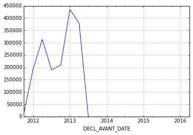

```python
avantages[avantages['BENEF_PS_QUALIFICATION'] == u'Pédiatrie']['DECL_AVANT_MONTANT'].resample('Q', how='sum').plot()
```

## Les contrats

### Répartition des contrats en Oncologie (en nombre de contrats)

```python
nbconventions = conventions[conventions['BENEF_PS_QUALIFICATION'] == u'Oncologie']['ORIGIN'].count()
contrats = conventions[conventions['BENEF_PS_QUALIFICATION'] == u'Oncologie'].groupby('DECL_CONV_OBJET')[['ORIGIN']].count().sort('ORIGIN', ascending=False)
contrats['%'] = contrats  * 100 / nbconventions
contrats
```

| DECL_CONV_OBJET | ORIGIN | % |
| --- | --- | --- |
| CONTRAT DE CONSULTANT | 672 | 27.826087 |
| EXPERT | 441 | 18.260870 |
| COLLABORATION SCIENTIFIQUE | 375 | 15.527950 |
| ORATEUR/FORMATEUR | 353 | 14.616977 |
| HOSPITALITÉ | 330 | 13.664596 |
| CONGRÈS - SYMPOSIUM | 222 | 9.192547 |
| DIVERS | 13 | 0.538302 |
| FORMATION | 2 | 0.082816 |
| PRÊT | 2 | 0.082816 |
| CONTRAT DE CESSION | 1 | 0.041408 |
| RELATIONS PUBLIQUES | 1 | 0.041408 |

### Dans l'oncologie, large place à des contrats d'expertise

```python
typecontrat = [u'CONTRAT DE CONSULTANT', u'EXPERT', u'COLLABORATION SCIENTIFIQUE', u'ORATEUR/FORMATEUR']
pc = 0
for t in typecontrat:
    pc += contrats[contrats.index == t]['%'].sum()
pc
```

```
76.231884057971016
```

Les contrats d'expertise (consultants, experts, collaborateurs scientifiques ou d'orateurs/formateur) représentent pour l'oncologie, 76,23%. Sur l'ensemble des contrats (quelque soit la profession ou la spécialité des bénéficiaires), ils ne représentent que 22%.

### Les contrats liés à la pédiatrie plus dans la norme

```python
nbconventions = conventions[conventions['BENEF_PS_QUALIFICATION'] == u'Pédiatrie']['ORIGIN'].count()
contrats = conventions[conventions['BENEF_PS_QUALIFICATION'] == u'Pédiatrie'].groupby('DECL_CONV_OBJET')[['ORIGIN']].count().sort('ORIGIN', ascending=False)
contrats['%'] = contrats  * 100 / nbconventions
contrats
```

| DECL_CONV_OBJET | ORIGIN | % |
| --- | --- | --- |
| HOSPITALITÉ | 731 | 50.518314 |
| CONTRAT DE CONSULTANT | 266 | 18.382861 |
| COLLABORATION SCIENTIFIQUE | 238 | 16.447823 |
| CONGRÈS - SYMPOSIUM | 123 | 8.500346 |
| ORATEUR/FORMATEUR | 71 | 4.906704 |
| EXPERT | 16 | 1.105736 |
| CONTRAT DE CESSION | 1 | 0.069109 |
| DIVERS | 1 | 0.069109 |

```python
pc = 0
for t in typecontrat:
    pc += contrats[contrats.index == t]['%'].sum()
pc
```

```
40.843123704215621
```

L'hopitalité et les congrès représentent 59% (sur les contrats déclarés à l'ensemble des professions de santé, c'est 48%). Les contrats d'expertise (populaires chez les oncologues) représentent 40% (au global, c'est 22%)

### Quels sont les labos qui ciblent l'oncologie ?

```python
nbconventions = conventions[conventions['BENEF_PS_QUALIFICATION'] == u'Oncologie']['ORIGIN'].count()
contrats_par_labos = conventions[conventions['BENEF_PS_QUALIFICATION'] == 'Oncologie'].groupby('LABO')[['DECL_CONV_OBJET']].count().sort('DECL_CONV_OBJET', ascending=False).head(15)
contrats_par_labos['%'] = contrats_par_labos * 100 / nbconventions
contrats_par_labos.head(10)
```

| LABO | DECL_CONV_OBJET | % |
| --- | --- | --- |
| SANOFI | 481 | 19.917184 |
| AMGEN | 388 | 16.066253 |
| NOVARTIS PHARMA | 379 | 15.693582 |
| ROCHE | 316 | 13.084886 |
| BOEHRINGER INGELHEIM | 282 | 11.677019 |
| IPSEN | 248 | 10.269151 |
| GLAXOSMITHKLINE | 134 | 5.548654 |
| PFIZER | 61 | 2.525880 |
| SERVIER | 27 | 1.118012 |
| CELGENE | 16 | 0.662526 |

```python
consultants_par_labos = pd.DataFrame(index=contrats_par_labos.index)
for l in contrats_par_labos.index:
    pc = 0
    nb = 0
    nbtot = conventions[(conventions['BENEF_PS_QUALIFICATION'] == u'Oncologie') & (conventions['LABO'] == l)]['ORIGIN'].count()
    contrats = conventions[(conventions['BENEF_PS_QUALIFICATION'] == u'Oncologie') & (conventions['LABO'] == l)].groupby('DECL_CONV_OBJET')[['ORIGIN']].count()
    for t in typecontrat:
        nb += contrats[contrats.index == t]['ORIGIN'].sum()
        pc += contrats[contrats.index == t]['ORIGIN'].sum() * 100 / nbtot
    consultants_par_labos.set_value(l, '%', pc)
    consultants_par_labos.set_value(l, 'nb', nb)
consultants_par_labos.sort('nb', ascending=False)
```

| LABO | % | nb |
| --- | --- | --- |
| SANOFI | 90 | 439 |
| AMGEN | 97 | 388 |
| NOVARTIS PHARMA | 98 | 379 |
| ROCHE | 94 | 304 |
| BOEHRINGER INGELHEIM | 25 | 74 |
| GLAXOSMITHKLINE | 42 | 57 |
| PFIZER | 91 | 57 |
| IPSEN | 17 | 44 |
| SERVIER | 95 | 26 |
| CELGENE | 99 | 16 |
| MUNDIPHARMA | 100 | 13 |
| LUNDBECK | 100 | 9 |
| Accuray | 100 | 9 |
| PSI CRO | 100 | 6 |
| SANDOZ | 16 | 1 |

*nb = nombre de contrats d'expertise*

*% = pourcentage des contrats d'expertise par rapport à l'ensemble des contrats*

**A part BOEHRINGER INGELHEIM, GLAXOSMITHKLINE, IPSEN, SANDOZ, les labos investissent très largement dans des contrats d'expertises.**

### Les contrats Sanofi à l'oncologie atypique par rapport à l'ensemble de leurs contrats

```python
(conventions, avantages) = labos2AvantagesAndConventions("SANOFI.anon.csv")
tot = conventions['ORIGIN'].count()
contrats = conventions.groupby('DECL_CONV_OBJET')[['ORIGIN']].count().sort('ORIGIN', ascending=False)
contrats['%'] = contrats * 100 / tot
contrats
```

| DECL_CONV_OBJET | ORIGIN | % |
| --- | --- | --- |
| CONTRAT DE CONSULTANT | 2326 | 45.341131 |
| HOSPITALITÉ | 1174 | 22.884990 |
| RÉUNION | 1056 | 20.584795 |
| COLLABORATION SCIENTIFIQUE | 536 | 10.448343 |
| CONGRÈS - SYMPOSIUM | 14 | 0.272904 |
| PRESTATION DE SERVICES | 6 | 0.116959 |
| DIVERS | 5 | 0.097466 |
| EXPERT | 3 | 0.058480 |
| FORMATION | 2 | 0.038986 |

```python
pc = 0
for t in typecontrat:
    pc += contrats[contrats.index == t]['%'].sum()
pc
```

```
55.847953216374272
```

On passe de 90% de contrats d'expertise chez les oncologues à 55% pour type de contrat toutes spécialités confondues.

### Répartition des contrats d'expertise Sanofi par spécialité médicale

```python
consultants_par_specialites = pd.DataFrame(index=conventions['BENEF_PS_QUALIFICATION'].unique())
for specialite in consultants_par_specialites.index:
    tot = conventions[conventions['BENEF_PS_QUALIFICATION'] == specialite]['ORIGIN'].count()
    contrats = conventions[conventions['BENEF_PS_QUALIFICATION'] == specialite].groupby('DECL_CONV_OBJET')[['ORIGIN']].count()
    pc = 0
    nb = 0
    for t in typecontrat:
        nb += contrats[contrats.index == t]['ORIGIN'].sum()
        pc += contrats[contrats.index == t]['ORIGIN'].sum() * 100 /tot
    consultants_par_specialites.set_value(specialite, 'nb', nb)
    consultants_par_specialites.set_value(specialite, '% contrat expertise', pc)
consultants_par_specialites.sort('nb', ascending=False)
```

|  | nb | % contrat expertise |
| --- | --- | --- |
| Endocrinologie | 633 | 88 |
| Médecine générale | 446 | 24 |
| Oncologie | 439 | 90 |
| Cardiologie | 146 | 89 |
| Urologie | 143 | 84 |
| Hépato-gastro-entérologie | 126 | 92 |
| Médecine interne | 116 | 81 |
| Hématologie | 85 | 96 |
| Neurologie | 83 | 94 |
| Anesthésie | 76 | 56 |
| Chirurgie viscérale et digestive | 52 | 85 |
| Chirurgie orthopédique et traumatologique | 48 | 48 |
| Néphrologie | 45 | 95 |
| Psychiatrie | 43 | 92 |
| Diabétologie | 33 | 90 |
| Chirurgie | 31 | 83 |
| Imagerie médicale | 26 | 81 |
| Pédiatrie | 25 | 92 |
| Ophtalmologie | 25 | 100 |
| Rhumatologie | 22 | 90 |
| Médecine infectieuse et tropicale | 20 | 90 |
| Gérontologie | 17 | 89 |
| Pharmacologie | 17 | 94 |
| Biologie médicale | 16 | 100 |
| Infirmier | 15 | 8 |
| Oto-rhino-laryngologie | 14 | 81 |
| Anatomo-pathologie | 14 | 87 |
| Pneumologie | 13 | 92 |
| Gynécologie | 12 | 70 |
| Dermatologie | 9 | 90 |
| Anesthésie-réanimation | 8 | 53 |
| Angiologie | 7 | 100 |
| Santé publique et médecine sociale | 6 | 100 |
| Chirurgie cardiovasculaire et thoracique | 5 | 71 |
| Génétique médicale | 4 | 100 |
| Médecine du travail | 3 | 60 |
| Non renseigné | 3 | 100 |
| Immunologie | 3 | 99 |
| Médecine du sport | 2 | 100 |
| Diététique | 2 | 66 |
| Chirurgie de la main et du membre supérieur | 2 | 100 |
| Pharmacien | 2 | 0 |
| Toxicologie - tabacologie - alcoologie | 1 | 100 |
| Traitement de la douleur | 1 | 100 |
| Stérilité | 1 | 100 |
| Acupuncture | 1 | 100 |
| Allergologie | 1 | 100 |
| Sexologie | 1 | 100 |
| Médecine physique et de réadaptation | 1 | 50 |
| Hygiène | 0 | 0 |
| Bactériologie | 0 | 0 |
| Ostéopathie | 0 | 0 |
| NaN | 0 | 0 |
| Interne | 0 | 0 |
| Préparation en pharmacie | 0 | 0 |
| Kinésithérapie | 0 | 0 |

*nb = nombre des contrats d'expertise*

*% = pourcentage des contrats d'expertise par rapport à l'ensemble des contrats*

### Les contrats AMGEN à Oncologie plus similaires par rapport à l'ensemble de leurs contrats

```python
(conventions, avantages) = labos2AvantagesAndConventions("AMGEN.anon.csv")
tot = conventions['ORIGIN'].count()
contrats = conventions.groupby('DECL_CONV_OBJET')[['ORIGIN']].count()
contrats['%'] = contrats * 100 /tot
contrats.sort('ORIGIN', ascending=False)
```

| DECL_CONV_OBJET | ORIGIN | % |
| --- | --- | --- |
| EXPERT | 696 | 43.445693 |
| ORATEUR/FORMATEUR | 347 | 21.660424 |
| HOSPITALITÉ | 195 | 12.172285 |
| COLLABORATION SCIENTIFIQUE | 126 | 7.865169 |
| CONTRAT DE CONSULTANT | 122 | 7.615481 |
| PRESTATION DE SERVICES | 43 | 2.684145 |
| STAND | 30 | 1.872659 |
| CONGRÈS - SYMPOSIUM | 27 | 1.685393 |
| PARTENARIAT | 4 | 0.249688 |

```python
pc = 0
for t in typecontrat:
    pc += contrats[contrats.index == t]['%'].sum()
pc
```

```
80.586766541822726
```

L'écart est moins important : on passe de 80% vs 97%.

Détails du % de contrats d'expertise par spécialité :

```python
consultants_par_specialites = pd.DataFrame(index=conventions['BENEF_PS_QUALIFICATION'].unique())
for specialite in consultants_par_specialites.index:
    tot = conventions[conventions['BENEF_PS_QUALIFICATION'] == specialite]['ORIGIN'].count()
    contrats = conventions[conventions['BENEF_PS_QUALIFICATION'] == specialite].groupby('DECL_CONV_OBJET')[['ORIGIN']].count()
    pc = 0
    nb = 0
    for t in typecontrat:
        nb += contrats[contrats.index == t]['ORIGIN'].sum()
        pc += contrats[contrats.index == t]['ORIGIN'].sum() * 100 /tot
    consultants_par_specialites.set_value(specialite, 'nb', nb)
    consultants_par_specialites.set_value(specialite, '% contrat expertise', pc)
consultants_par_specialites.sort('nb', ascending=False)
```

|  | nb | % contrat expertise |
| --- | --- | --- |
| Oncologie | 388 | 97 |
| Rhumatologie | 236 | 97 |
| Néphrologie | 189 | 98 |
| Hématologie | 85 | 98 |
| Médecine générale | 80 | 32 |
| Cardiologie | 55 | 95 |
| Hépato-gastro-entérologie | 42 | 98 |
| Pneumologie | 40 | 99 |
| Médecine interne | 35 | 99 |
| Urologie | 24 | 98 |
| Endocrinologie | 15 | 99 |
| Imagerie médicale | 15 | 100 |
| Anatomo-pathologie | 11 | 99 |
| Dermatologie | 10 | 100 |
| Chirurgie orthopédique et traumatologique | 6 | 99 |
| Chirurgie viscérale et digestive | 5 | 100 |
| Chirurgie | 5 | 100 |
| Gérontologie | 5 | 100 |
| Neurologie | 5 | 100 |
| Psychiatrie | 5 | 100 |
| Gynécologie | 4 | 100 |
| Biologie médicale | 3 | 99 |
| Ophtalmologie | 2 | 100 |
| Pédiatrie | 2 | 100 |
| Santé publique et médecine sociale | 2 | 100 |
| Paléontologie | 2 | 100 |
| Psychologie | 2 | 100 |
| Pharmacien | 1 | 5 |
| Chirurgie maxillo-faciale | 1 | 100 |
| Physiologie | 1 | 100 |
| Anesthésie | 1 | 100 |
| Médecine militaire | 1 | 100 |
| NaN | 0 | 0 |
| Infirmier | 0 | 0 |

### Typologie assez homogène pour NOVARTIS PHARMA

```python
labo = pd.read_csv("NOVARTIS_PHARMA.anon.csv", encoding='utf-8')
laboc = labo.dropna(subset = ['DECL_CONV_DATE'])
laboc = laboc[laboc.DECL_CONV_DATE.str.contains(r'^20\d\d-')]

conventions = laboc[['LABO', 'DECL_CONV_DATE','DECL_CONV_OBJET', 'BENEF_PS_QUALIFICATION', 'ORIGIN']]
conventions.index = pd.to_datetime(conventions['DECL_CONV_DATE'])
tot = conventions['ORIGIN'].count()
contrats = conventions.groupby('DECL_CONV_OBJET')[['ORIGIN']].count()
contrats['%'] = contrats * 100 /tot
contrats.sort('ORIGIN', ascending=False)
```

| DECL_CONV_OBJET | ORIGIN | % |
| --- | --- | --- |
| COLLABORATION SCIENTIFIQUE | 5039 | 48.059132 |
| ORATEUR/FORMATEUR | 4193 | 39.990463 |
| CONTRAT DE CONSULTANT | 1126 | 10.739151 |
| HOSPITALITÉ | 111 | 1.058655 |
| PRESTATION DE SERVICES | 14 | 0.133524 |
| PARTENARIAT | 2 | 0.019075 |

```python
pc = 0
for t in typecontrat:
    pc += contrats[contrats.index == t]['%'].sum()
pc
```

```
98.788745827372438
```

98% vs 98%

Répartition des contrats d'expertise par spécialite :

```python
consultants_par_specialites = pd.DataFrame(index=conventions['BENEF_PS_QUALIFICATION'].unique())
for specialite in consultants_par_specialites.index:
    tot = conventions[conventions['BENEF_PS_QUALIFICATION'] == specialite]['ORIGIN'].count()
    contrats = conventions[conventions['BENEF_PS_QUALIFICATION'] == specialite].groupby('DECL_CONV_OBJET')[['ORIGIN']].count()
    pc = 0
    nb = 0
    for t in typecontrat:
        nb += contrats[contrats.index == t]['ORIGIN'].sum()
        pc += contrats[contrats.index == t]['ORIGIN'].sum() * 100 /tot
    if nb:
        consultants_par_specialites.set_value(specialite, 'nb', nb)
        consultants_par_specialites.set_value(specialite, '% contrat expertise', pc)

consultants_par_specialites.sort('nb', ascending=False)
```

|  | nb | % contrat expertise |
| --- | --- | --- |
| Pneumologie | 1116 | 99 |
| Endocrinologie | 1064 | 99 |
| Neurologie | 902 | 98 |
| Cardiologie | 599 | 99 |
| Ophtalmologie | 535 | 99 |
| Oncologie | 379 | 98 |
| Rhumatologie | 369 | 99 |
| Hématologie | 299 | 99 |
| Néphrologie | 211 | 98 |
| Médecine interne | 166 | 99 |
| Hépato-gastro-entérologie | 101 | 98 |
| Pédiatrie | 94 | 98 |
| Gérontologie | 93 | 99 |
| Diabétologie | 77 | 98 |
| Urologie | 40 | 99 |
| Anatomo-pathologie | 38 | 98 |
| Imagerie médicale | 32 | 99 |
| Gynécologie | 30 | 100 |
| Anesthésie | 28 | 99 |
| Médecine générale | 28 | 20 |
| Psychiatrie | 28 | 99 |
| Chirurgie | 20 | 100 |
| Sexologie | 19 | 100 |
| Chirurgie viscérale et digestive | 17 | 99 |
| Médecine infectieuse et tropicale | 13 | 99 |
| Médecine physique et de réadaptation | 12 | 99 |
| Dermatologie | 11 | 99 |
| Pharmacologie | 10 | 66 |
| Chirurgie cardiovasculaire et thoracique | 9 | 100 |
| Anesthésie-réanimation | 9 | 99 |
| Infirmier | 5 | 83 |
| Angiologie | 5 | 100 |
| Médecine du travail | 5 | 100 |
| Chirurgie orthopédique et traumatologique | 5 | 100 |
| Génétique médicale | 3 | 99 |
| Immunologie | 3 | 100 |
| Chirurgie maxillo-faciale | 2 | 100 |
| Allergologie | 2 | 100 |
| Diététique | 2 | 100 |
| Physiologie | 1 | 100 |
| Stomatologie | 1 | 100 |
| Exploration fonctionnelle | 1 | 100 |
| Oto-rhino-laryngologie | 1 | 100 |
| Bactériologie | 1 | 100 |
| Médecine du sport | 1 | 100 |
| Soins palliatifs | 1 | 100 |
| Andrologie | 1 | 100 |
| NaN | NaN | NaN |

### Idem pour ROCHE

```python
labo = pd.read_csv("ROCHE.anon.csv", encoding='utf-8')
laboc = labo.dropna(subset = ['DECL_CONV_DATE'])
laboc = laboc[laboc.DECL_CONV_DATE.str.contains(r'^20\d\d-')]

conventions = laboc[['LABO', 'DECL_CONV_DATE','DECL_CONV_OBJET', 'BENEF_PS_QUALIFICATION', 'ORIGIN']]
conventions.index = pd.to_datetime(conventions['DECL_CONV_DATE'])
tot = conventions['ORIGIN'].count()
contrats = conventions.groupby('DECL_CONV_OBJET')[['ORIGIN']].count() * 100 /tot
contrats.sort('ORIGIN', ascending=False)
```

| DECL_CONV_OBJET | ORIGIN |
| --- | --- |
| ORATEUR/FORMATEUR | 38.444320 |
| COLLABORATION SCIENTIFIQUE | 28.763290 |
| EXPERT | 26.580862 |
| RÉUNION | 3.693341 |
| DIVERS | 1.231114 |
| PRESTATION DE SERVICES | 0.559597 |
| CONGRÈS - SYMPOSIUM | 0.391718 |
| ÉDITION | 0.111919 |
| CONTRAT DE CONSULTANT | 0.055960 |
| PARTENARIAT | 0.055960 |

```python
pc = 0
for t in typecontrat:
    pc += contrats[contrats.index == t]['ORIGIN'].sum()
pc
```

```
93.844432008953561
```

93% vs 94%

Répartition des contrats d'expertise par spécialité :

```python
consultants_par_specialites = pd.DataFrame(index=conventions['BENEF_PS_QUALIFICATION'].unique())
for specialite in consultants_par_specialites.index:
    tot = conventions[conventions['BENEF_PS_QUALIFICATION'] == specialite]['ORIGIN'].count()
    contrats = conventions[conventions['BENEF_PS_QUALIFICATION'] == specialite].groupby('DECL_CONV_OBJET')[['ORIGIN']].count()
    pc = 0
    nb = 0
    for t in typecontrat:
        nb += contrats[contrats.index == t]['ORIGIN'].sum()
        pc += contrats[contrats.index == t]['ORIGIN'].sum() * 100 /tot
    consultants_par_specialites.set_value(specialite, 'nb', nb)
    consultants_par_specialites.set_value(specialite, '% contrat expertise', pc)
consultants_par_specialites.sort('nb', ascending=False)
```

|  | nb | % contrat expertise |
| --- | --- | --- |
| Oncologie | 304 | 94 |
| Rhumatologie | 233 | 98 |
| Hépato-gastro-entérologie | 208 | 98 |
| Néphrologie | 155 | 99 |
| Pneumologie | 155 | 98 |
| Dermatologie | 89 | 98 |
| Hématologie | 82 | 96 |
| Anatomo-pathologie | 54 | 99 |
| Psychiatrie | 44 | 94 |
| Médecine interne | 35 | 99 |
| Médecine générale | 32 | 38 |
| Chirurgie | 25 | 88 |
| Imagerie médicale | 24 | 99 |
| Neurologie | 17 | 99 |
| Cardiologie | 17 | 98 |
| Médecine infectieuse et tropicale | 14 | 99 |
| Biologie médicale | 14 | 99 |
| Chirurgie viscérale et digestive | 12 | 99 |
| Hépatologie | 11 | 99 |
| Endocrinologie | 7 | 99 |
| Infirmier | 6 | 28 |
| Interne | 5 | 100 |
| Gynécologie | 5 | 100 |
| Non renseigné | 4 | 100 |
| Pharmacologie | 4 | 33 |
| Santé publique et médecine sociale | 4 | 100 |
| Anesthésie-réanimation | 4 | 100 |
| Anapathologie | 3 | 99 |
| Services généraux | 3 | 33 |
| Virologie | 2 | 100 |
| Chirurgie orthopédique et traumatologique | 2 | 100 |
| Immunologie | 2 | 100 |
| Ophtalmologie | 2 | 100 |
| Diabétologie | 1 | 100 |
| Praticien hospitalier | 1 | 100 |
| Urologie | 1 | 100 |
| Médecine d'urgence | 1 | 100 |
| Épidémiologie | 1 | 100 |
| Pédiatrie | 1 | 100 |
| Toxicologie - tabacologie - alcoologie | 1 | 100 |
| Recherche médicale | 1 | 100 |
| Chirurgie plastique reconstructrice et esthétique | 1 | 100 |
| Génétique médicale | 1 | 100 |
| Philosophie | 1 | 100 |
| NaN | 0 | 0 |
| Préparation en pharmacie | 0 | 0 |